# Schmidt_Emily_TP7

Emily Schmidt

2023-05-04

## 0.1 Libraries

```r
library(fpp3)
library(ggplot2)
library(tsibble)
library(dplyr)
library(scales)
```

# 1 Exercise 3

Choose a series from us_employment, the total employment in different industries in the United States.

```r
?us_employment # Review
```

```
## starting httpd help server ... done
```

```r
class(us_employment) # Check the type of object, ts
```

```
## [1] "tbl_ts"     "tbl_df"     "tbl"        "data.frame"
```

```r
head(us_employment)
```

```
## # A tsibble: 6 x 4 [1M]
## # Key:       Series_ID [1]
##      Month Series_ID     Title         Employed
##      <mth> <chr>         <chr>            <dbl>
## 1 1939 Jan CEU0500000001 Total Private    25338
## 2 1939 Feb CEU0500000001 Total Private    25447
## 3 1939 Mar CEU0500000001 Total Private    25833
## 4 1939 Apr CEU0500000001 Total Private    25801
## 5 1939 May CEU0500000001 Total Private    26113
## 6 1939 Jun CEU0500000001 Total Private    26485
```

```r
#unique(us_employment$Title)

private <- us_employment |>
  filter(Title == "Total Private")

# Check number of missing values (1, removed Growth)
sum(is.na(private)) # 0 values
```

```
## [1] 0
```

```r
# Keep only Month, Title and Employed
private_Emp <- private[,c(1,3,4)]

rm(private)
```

```r
# Plot the US Total Private employment data, Section 9.9
private_Emp |>
  mutate(Employed = Employed/1000) |>
  select(Month, Employed)
```

```
## # A tsibble: 969 x 2 [1M]
##       Month Employed
##       <mth>    <dbl>
##  1 1939 Jan     25.3
##  2 1939 Feb     25.4
##  3 1939 Mar     25.8
##  4 1939 Apr     25.8
##  5 1939 May     26.1
##  6 1939 Jun     26.5
##  7 1939 Jul     26.5
##  8 1939 Aug     26.8
##  9 1939 Sep     27.5
## 10 1939 Oct     27.8
## # ℹ 959 more rows
```

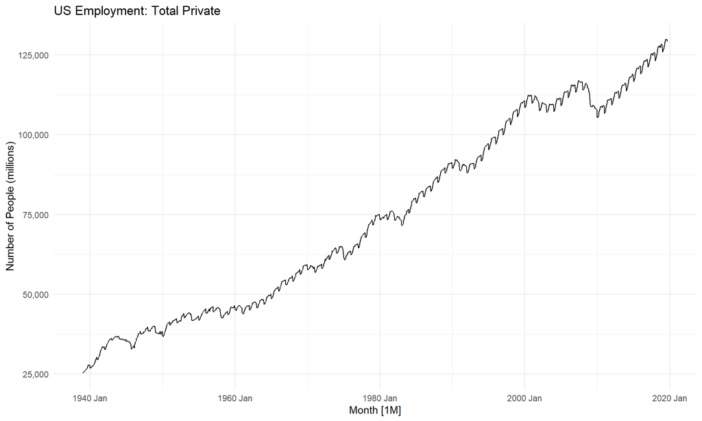

```r
autoplot(private_Emp, Employed) +
  labs(title = "US Employment: Total Private",
       y="Number of People (millions)") +
  scale_y_continuous(labels = comma) +
  theme_minimal()
```

The total private sector includes all industries and businesses that are not part of the government sector.

## 1.1 Question 1

Produce an STL decomposition of the data and describe the trend and seasonality.

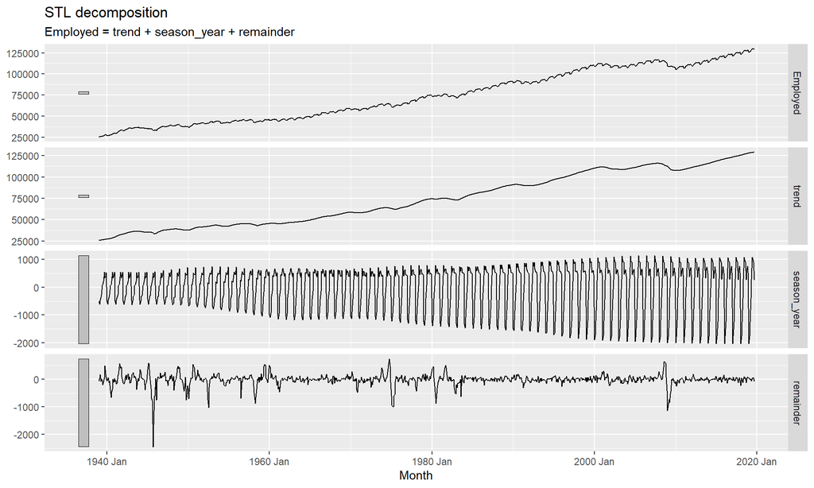

```r
# Section 3.6 code
private_Emp |>
  model(
    STL(Employed ~ trend(window = 12) + # Monthly data
                   season(window = 12), # Monthly data
    robust = TRUE)) |>
    components() |> autoplot()
```

The STL model shows an overall upward trend with seasonality. The seasonality is more difficult to see within the decomposition output. Therefore, please review to the US Employment: Total Private chart above. The seasonality is easily explained through holiday hiring, tourism, and specific industries that need workers only in certain seasons. There are several decreases in the trend that almost appear to be cyclic. However, these do not occur at a known period. Instead, there have been events such as wars, 9/11, recessions, etc. that make those decreases in employment not just happenstance to seasonality. In addition, something appears to be occurring in the season_year plot, as the amplitudes of the seasonality widens as time passes. There appears to be no patterns within the remainder component.

## 1.2 Question 2

Do the data need transforming? If so, find a suitable transformation.

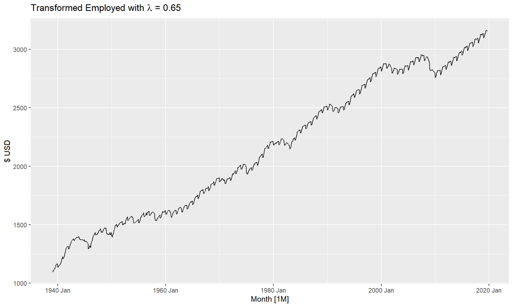

```r
#Box-Cox Transformation, Turkey GDP
lambda <- private_Emp |>
  features(Employed, features = guerrero) |>
  pull(lambda_guerrero)

private_lambda <- private_Emp |>
  autoplot(box_cox(private_Emp$Employed, lambda)) +
  labs(y = "$ USD",
       title = latex2exp::TeX(paste0(
         "Transformed Employed with $\\lambda$ = ",
         round(lambda,2))))

private_lambda
```

Yes, transformation may be necessary due to the calendar adjustments, which would effectively remove variation. In order to see this, the Guerrero feature is used. This calculates the optimal value of $\lambda$ for Box-Cox transformation by employing the Guerrero method, with a resulting value of 0.65 identified as best choice for this time series. This method selects the lambda which minimizes the coefficient of variation for subseries of employment. A good value of $\lambda$ is one that makes the size of the seasonal variation about the same size across the series. In turn, this makes forecasting quite easier!

## 1.3 Question 3

Are the data stationary? If not, find an appropriate differencing which yields stationary data.

Since this time series has trend and seasonality, it is not considered stationary since it depends on the time at which the series is observed.

```r
private_Emp |>
  features(Employed, unitroot_ndiffs)
```

```
## # A tibble: 1 × 1
##   ndiffs
##    <int>
## 1      1
```

It appears that only one first differences is carried out.

```r
private_Emp |>
  features(Employed, unitroot_nsdiffs)
```

```
## # A tibble: 1 × 1
##   nsdiffs
##     <int>
## 1       1
```

It appears that only one seasonal differencing is needed.

```r
private_Emp |>
  features(Employed, unitroot_kpss)
```

```
## # A tibble: 1 × 2
##   kpss_stat kpss_pvalue
##       <dbl>       <dbl>
## 1      12.2        0.01
```

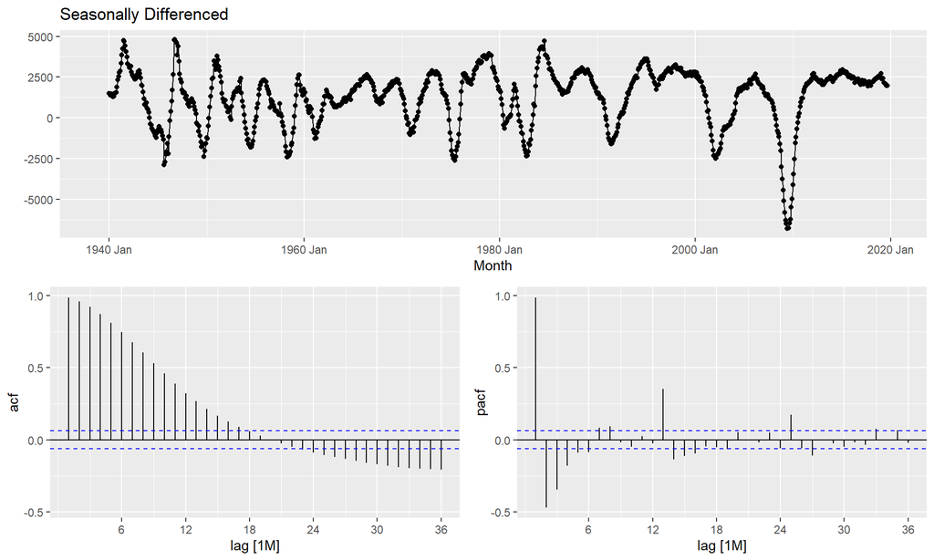

```r
# Seasonal difference
private_Emp |>
  gg_tsdisplay(difference(Employed, 12),
               plot_type = 'partial', lag = 36) +
  labs(title = "Seasonally Differenced", y = "")
```

These continue to not be stationary when reviewing the ACF chart, so we continue to take another first difference.

```r
private_Emp |>
  mutate(diff_employed = difference(Employed, 12)) |>
  features(diff_employed, unitroot_kpss)
```

```
## # A tibble: 1 × 2
##   kpss_stat kpss_pvalue
##       <dbl>       <dbl>
## 1     0.193         0.1
```

After differencing once with seasonality, the resulting p-value has reached 0.1. Based on the ACF though, we will go one step further to analyze what happens when the time series is seasonal and first differeneced.

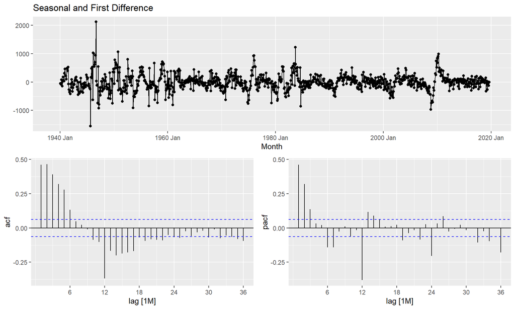

```r
# Seasonal and first difference
private_Emp |>
  gg_tsdisplay(difference(Employed, 12) |> difference(),
               plot_type = 'partial', lag = 36) +
  labs(title = "Seasonal and First Difference", y="")
```

Within PACF, there are spikes at lags 12 and 24, and this lag 12 also appears in ACF. This may suggest that AR(2) and MA(1). In terms of non-seasonal lags, there are at least three (3) in PACF, and the ACF is not indicative of any simple model.

```r
private_Emp |>
  mutate(diff_employed = difference(Employed, 12)) |>
  mutate(diff2_employed = difference(diff_employed)) |>
  features(diff2_employed, unitroot_kpss)
```

```
## # A tibble: 1 × 2
##   kpss_stat kpss_pvalue
##       <dbl>       <dbl>
## 1    0.0113         0.1
```

After the first and seasonal difference, the test statistic is tiny, and well within the range we would expect for stationary data, so the p-value is greater or equal to 0.1. We can conclude that the differenced data appear stationary. Since there still appears to be structure in the ACF plot, we difference one more time. This extra difference may not be necessary, but interesting to review.

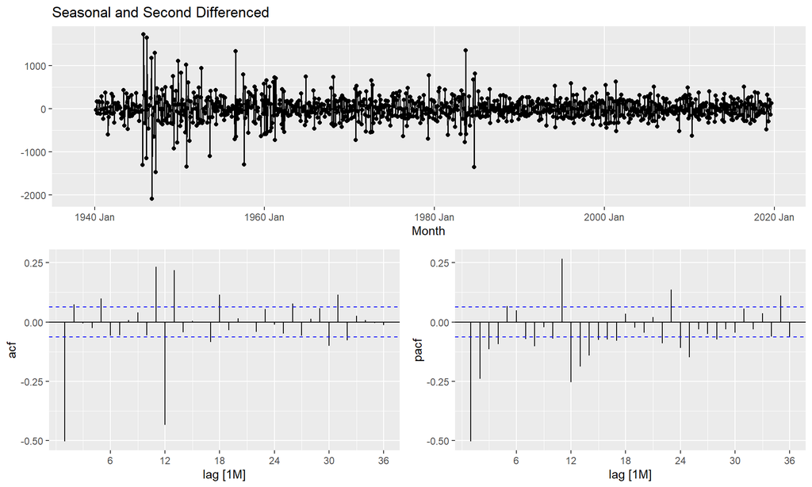

```r
# Seasonal and second difference
private_Emp |>
  gg_tsdisplay(difference(Employed, 12) |> difference() |> difference(),
               plot_type = 'partial', lag = 36) +
  labs(title = "Seasonal and Second Differenced", y="")
```

Typically, determining suitable values for $p$ and $q$ based only on a time plot is not feasible. Nonetheless, in some instances, one can leverage the ACF and PACF plots, which are closely connected, to identify appropriate values for $p$ and $q$. $p$ is the order of the autoregressive part while $q$ is the order of the moving average part.

```r
private_Emp |>
  mutate(diff_employed = difference(Employed, 12)) |>
  mutate(diff2_employed = difference(diff_employed)) |>
  mutate(diff3_employed = difference(diff2_employed)) |>
  features(diff3_employed, unitroot_kpss)
```

```
## # A tibble: 1 × 2
##   kpss_stat kpss_pvalue
##       <dbl>       <dbl>
## 1   0.00434         0.1
```

The test statistic continues to decrease, and we would expect that the data is still stationary since the p-value is greater or equal to 0.1.

## 1.4 Question 4

Identify several ARIMA models that might be useful in describing the time series. Which of your models is the best according to their AICc values?

Earlier in the ACF and PACF, there were elements that will be helpful to distinguish before moving forward with building the ARIMA models. In the seasonal and first differenced output, there are significants spikes at lag 12 and 24 within the PACF, indicating that there is a seasonal AR(12), while the MA would possibly be one since there is a spike at 12. If we incorporate the first difference, a seasonal difference, and the non-seasonal and seasonal components, the model would be $ARIMA(3, 1, 0)(2, 1, 0)_{12}$. The first part of this model outlines what is non-seasonal, and the second part aligns with seasonality, hence the 12. The one’s within the ARIMA model show the $d$ and $D$, the number of ordinary and seasonal differences which were used in the last question.

```r
private_Emp |>
  model(
    arima011011 = ARIMA(Employed ~ pdq(0,1,1) + PDQ(0,1,1)),
    arima310210 = ARIMA(Employed ~ pdq(3,1,0) + PDQ(2,1,0)),
    arima010011 = ARIMA(Employed ~ pdq(0,1,0) + PDQ(0,1,1)),
    arima210011 = ARIMA(Employed ~ pdq(2,1,0) + PDQ(0,1,1)),
    arima210110 = ARIMA(Employed ~ pdq(2,1,0) + PDQ(1,1,0)),
    auto = ARIMA(Employed)) -> arima_fit

glance(arima_fit)
```

```
## # A tibble: 6 × 8
##   .model      sigma2 log_lik    AIC   AICc    BIC ar_roots   ma_roots
##   <chr>        <dbl>   <dbl>  <dbl>  <dbl>  <dbl> <list>     <list>
## 1 arima011011 53759.  -6567. 13140. 13140. 13154. <cpl [0]>  <cpl [13]>
## 2 arima310210 46643.  -6495. 13001. 13001. 13031. <cpl [27]> <cpl [0]>
## 3 arima010011 62521.  -6640. 13284. 13284. 13294. <cpl [0]>  <cpl [12]>
## 4 arima210011 43942.  -6469. 12947. 12947. 12966. <cpl [2]>  <cpl [12]>
## 5 arima210110 50682.  -6535. 13077. 13077. 13097. <cpl [14]> <cpl [0]>
## 6 auto        41819.  -6452. 12920. 12921. 12959. <cpl [2]>  <cpl [26]>
```

Between the six models, it would appear that the auto model performs the best in terms of AICc. The one that I believed to be correct had the third lowest AICc.

```r
fit <- private_Emp |>
  model(ARIMA(Employed))

report(fit)
```

```
## Series: Employed
## Model: ARIMA(2,0,2)(0,1,2)[12] w/ drift
##
## Coefficients:
##          ar1      ar2      ma1     ma2     sma1     sma2  constant
##       1.8628  -0.8683  -0.6127  0.0943  -0.6341  -0.0779    6.9251
## s.e.  0.0262   0.0260   0.0406  0.0360   0.0326   0.0312    0.9256
##
## sigma^2 estimated as 41819:  log likelihood=-6452.23
## AIC=12920.47   AICc=12920.62   BIC=12959.38
```

The automatic selection procedure seems to produce the best model due to the lowest AICc. The model is a $ARIMA(2, 0, 2)(0, 1, 2)_{12}$ with drift. When using the ARIMA() function, it uses unitroot_nsdiffs() to determine the D (seasonal differences) while unitroot_ndiffs() is for the ordinary differences. Prior to running the auto model, it appeared that ordinary differencing twice for seasonality was not the best choice, and neither was just applying seasonality differencing.

## 1.5 Question 5

Estimate the parameters of your best model and do diagnostic testing on the residuals. Do the residuals resemble white noise? If not, try to find another ARIMA model which fits better.

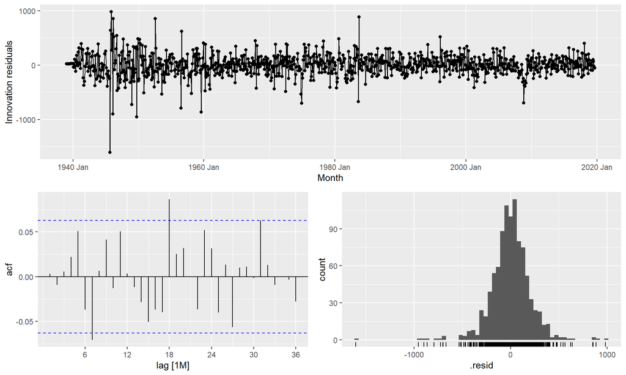

```r
arima_fit |> select(auto) |> gg_tsresiduals(lag = 36)
```

```r
augment(arima_fit) |>
  filter(.model == "auto") |>
  features(.innov, ljung_box, lag = 36, dof = 7)
```

```
## # A tibble: 1 × 3
##   .model lb_stat lb_pvalue
##   <chr>    <dbl>     <dbl>
## 1 auto      44.3    0.0341
```

```r
private_Emp |>
  model(
    arima301012 = ARIMA(Employed ~ pdq(3,0,1) + PDQ(0,1,2)),
    arima202112 = ARIMA(Employed ~ pdq(2,0,2) + PDQ(0,1,2)),
    auto = ARIMA(Employed)) -> arima_fit2

glance(arima_fit2)
```

```
## # A tibble: 3 × 8
##   .model      sigma2 log_lik    AIC   AICc    BIC ar_roots  ma_roots
##   <chr>        <dbl>   <dbl>  <dbl>  <dbl>  <dbl> <list>    <list>
## 1 arima301012 41845.  -6453. 12921. 12921. 12960. <cpl [3]> <cpl [25]>
## 2 arima202112 41819.  -6452. 12920. 12921. 12959. <cpl [2]> <cpl [26]>
## 3 auto        41819.  -6452. 12920. 12921. 12959. <cpl [2]> <cpl [26]>
```

```r
augment(arima_fit2) |>
  filter(.model == "arima301012") |>
  features(.innov, ljung_box, lag = 36, dof = 7)
```

```
## # A tibble: 1 × 3
##   .model      lb_stat lb_pvalue
##   <chr>         <dbl>     <dbl>
## 1 arima301012    44.4    0.0337
```

After running a different model, $ARIMA(3, 0, 1)(0, 1, 2)_{12}$, which was extremely close to the auto model, it still failed the Ljung-Box test for 36 lags. According to section 9.9, sometimes it is not possible to find a model that passes all of the tests.

## 1.6 Question 6

Forecast the next 3 years of data. Get the latest figures to check the accuracy of your forecasts.

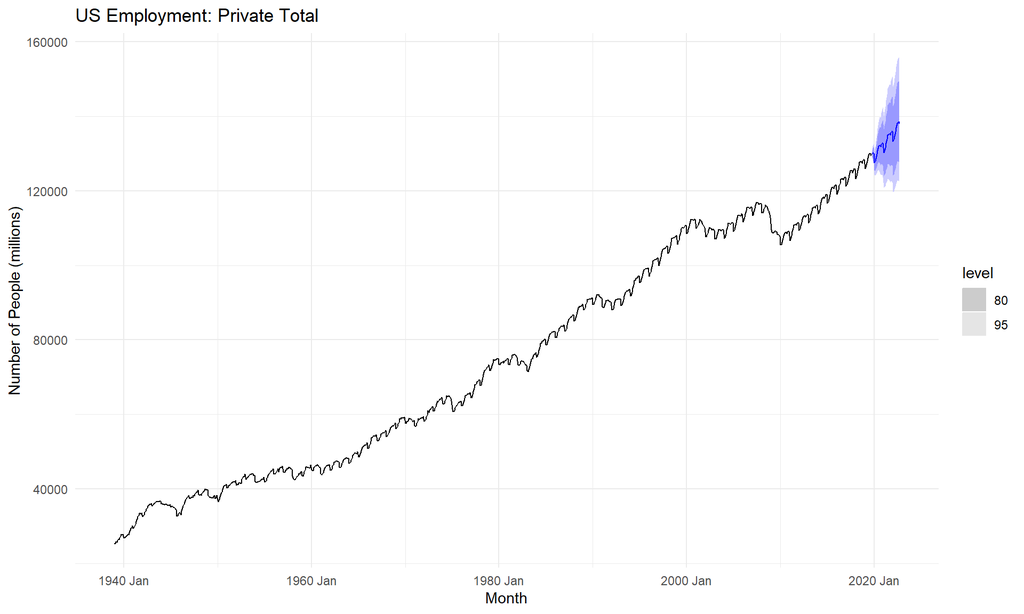

```r
private_Emp |>
  model(ARIMA(log(Employed) ~ 1 + pdq(2,0,2) + PDQ(0,1,2))) |>
  forecast(h = "3 years") |>
  autoplot(private_Emp) +
  labs(title = "US Employment: Private Total",
       y = "Number of People (millions)") +
  theme_minimal()
```

```r
PI <- private_Emp |>
  model(ARIMA(log(Employed) ~ 1 + pdq(2,0,2) + PDQ(0,1,2))) |>
  forecast(h = "3 years") |>
  mutate(PI = hilo(Employed, level = 95))
PI
```

```
## # A fable: 36 x 5 [1M]
## # Key:     .model [1]
##    .model                  Month          Employed  .mean                     PI
##    <chr>                   <mth>            <dist>  <dbl>                 <hilo>
##  1 ARIMA(log(Employed)… 2019 Oct t(N(12, 2.1e-05)) 1.30e5 [128642.6, 130974.1]95
##  2 ARIMA(log(Employed)… 2019 Nov t(N(12, 5.4e-05)) 1.30e5 [128249.8, 132002.1]95
##  3 ARIMA(log(Employed)… 2019 Dec   t(N(12, 1e-04)) 1.30e5 [127502.4, 132657.2]95
##  4 ARIMA(log(Employed)… 2020 Jan t(N(12, 0.00016)) 1.27e5 [124308.5, 130704.3]95
##  5 ARIMA(log(Employed)… 2020 Feb t(N(12, 0.00024)) 1.28e5 [124141.3, 131859.2]95
##  6 ARIMA(log(Employed)… 2020 Mar t(N(12, 0.00032)) 1.29e5 [124283.3, 133292.3]95
##  7 ARIMA(log(Employed)… 2020 Apr t(N(12, 0.00041)) 1.30e5 [124791.8, 135067.6]95
##  8 ARIMA(log(Employed)… 2020 May   t(N(12, 5e-04)) 1.31e5 [125178.1, 136657.7]95
##  9 ARIMA(log(Employed)… 2020 Jun   t(N(12, 6e-04)) 1.32e5 [125733.5, 138377.5]95
## 10 ARIMA(log(Employed)… 2020 Jul   t(N(12, 7e-04)) 1.32e5 [125383.6, 139039.8]95
## # ℹ 26 more rows
```

According to FRED, Total Private employment dropped drastically in February 2020, and this was due to COVID-19. Without this event, employment in this sector may have continued to increase. Since this pandemic occurred though, the latest numbers the government website has is from September 2022, at 131,445 employed [1]. This value falls within the 95% confidence interval, 122,022.1 to 155,500.6.

**Resource** [1]: https://fred.stlouisfed.org/series/USPRIV

## 1.7 Question 7

Eventually, the prediction intervals are so wide that the forecasts are not particularly useful. How many years of forecasts do you think are sufficiently accurate to be usable?

Since drastic events like wars, economy crises, or pandemics are arguably unpredictable especially when it comes to unemployment, it would most likely be advised to not forecast past one year. Ultimately, it will be dependent on various factors if this threshold is more or less. Over the times series, there were patterns (like seasonality) that could be accounted for. However, if there is a sudden drop that caused layoffs, this would be unpredictable.